# Cold Hardiness Dynamics of Two Conifer Species From an Altitudinal Gradient

# Summary

## Background and Data Collection Procedure

An observational study was conducted to assess the effects of chill accumulation on cold hardiness in buds for two species of conifers: balsam fir (*Abies balsamea*) and red spruce (*Picea rubens*). Cuttings from trees along gradient of altitudes on Mt. Washington were collected. These cuttings contained one to three buds depending on the species and individual tree. Some buds were expended to measure “in-the-field” cold hardiness, which provides a snapshot in time. Other buds were retained and subjected to “forcing conditions”. These forcing conditions mimic warm and humid weather (i.e. spring/summer) and allow researchers to assess how quickly a tree loses its cold hardiness. The rate at which hardiness is lost is called the deacclimation rate.

This collection and measurement process was conducted at ten time points spanning August 21, 2020 to February 5, 2021. This allows us to estimate both “in-the-field” cold hardiness and lab-induced deacclimation rates along a (i) gradient of thirteen altitudes at (ii) ten time points for (iii) two species of conifers.

## Result 1: Cold Hardiness Improves with Accumulated Chill

To answer the client’s first question regarding weather’s impact on cold hardiness, we fit a linear mixed effects model. Specifically, we consider `Species`, `Chill accumulation`, and an interaction between the two as fixed effects. `Tree ID` and `Collection round` are modeled as random effects. We find that the `Chill accumulation` and interaction term are significant ($p = 0.0002; p < 10^{-15}$ respectively). One unit of accumulated chill corresponds to a $-0.08$ degree change in cold hardiness. This expected rate of change is more extreme for *Picea rubens*, as its expected cold hardiness changes by an additional $-0.14$ degrees.

## Result 2: There Are Ecotype Driven Variations in Deacclimation Rate

To answer the second question regarding variations in deacclimation rate accounted for by ecotype but not weather, we model deacclimation rate as a linear combinatoion of altitude (here encoded as categorical), chill accumulation, and species. We find that there are differences in deacclimation rates that are accounted for by altitude that *are not* accounted for by chill accumulation ($p < 10^{-15}$). In other words, there are ecotype effects that are not explained by weather (i.e. chill accumulation).

# Background

Cold hardiness refers to the ability of a plant’s buds to survive cold weather; it is the lowest temperature a bud can be exposed to before it dies. Buds need to survive through the winter because, among other things, they harbor meristems (akin to stem cells in humans) that allow a plant to grow and repair. Cold hardiness is not a fixed quantity. Rather, it changes throughout the year as a plant undergoes multiple seasons, etc. Generally, more exposure to cold leads to more tolerance to cold.

In addition to cold hardiness, a bud’s resilience to cold can also be assessed by measuring its deacclimation rate. This is the rate at which a bud loses it’s cold hardiness. This can be estimated by measuring cold hardiness throughout the spring and summer as temperatures rise. However, it can also be estimated by exposing buds to artificial warm-weather conditions and tracking the extent to which cold hardiness lessens as duration under warm-weather. This rate is generally linear with respect to the number of days a bud is subjected to “forcing conditions”.

# Experimental Design & Data Collection

A fixed grid of altitudes was selected along Mt. Washington in New Hampshire. Selecting altitudes on the same mountain is meant to control for potential confounders (e.g. amount of sunlight, wind, extreme weather events) as much as possible while studying the effects of temperature. Since temperature varies at different elevations, there is a naturally occurring experiment where the independent variable is temperature (or accumulated chill) and the dependent variables is cold hardiness (or deacclimation rate).

For each altitude, one to three trees were selected based on accessibility from the main access road (1600, 4250, 4800, 5100, 5300 feet altitudes do not contain measurements for *Picea rubens*). The client retrieved as many cuttings as necessary to run further assays. Specifically, for each biological replicate (i.e. tree), the client collected cuttings until there were enough buds to have approximately 10 sub-samples (i.e. buds) for each forcing condition. The same person performed all collections and ran all experiments, so we do not expect any technician-induced variation or batch effects.

It is worth noting that the trees used in the experiment are not randomly selected. Rather, they were chosen based on ease of access and proximity to a road running up Mt. Washington. In this way, the sample could be a poor representation of the population of trees on Mt. Washington. For example, the access road was probably built along a line of the mountain where it was easier to build. Perhaps there was less forest coverage or less shale to blast through. This could in turn mean that the sample of trees–the ones close to the access road–are not representative of the population of trees. While it is not a random sample from the population, it is still representative enough to proceed with analysis.

After cuttings were retrieved, they were stored in such a way (i.e. kept at a 2C freezer) so as not to alter cold hardiness while they were transported to the lab. A random subset of the collected buds are expended immediately to measure cold hardiness. The rest of the buds are randomly assigned to forcing conditions, where they spend as few as two and as many as 74 days stored in conditions mimicking summer days (16 hours of light; 22 degrees Celsius) to induce loss of cold hardiness. The rate at which cold hardiness is lost is called the deacclimation rate. In short, there are two quantities of interest: cold hardiness and deacclimation rate.

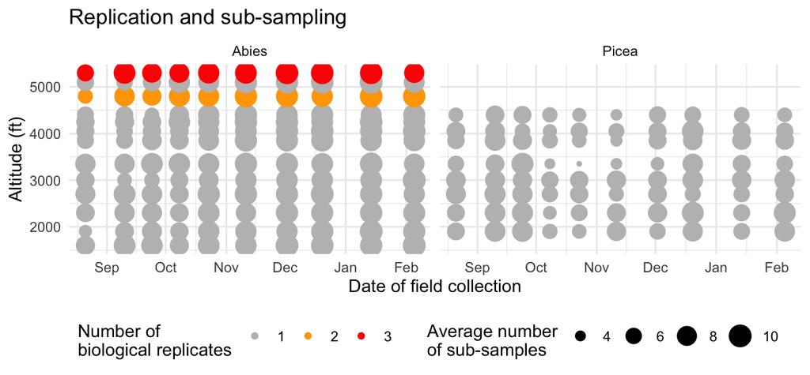

Figure 1: Replication and sub-sampling procedure. Each circle represents the number of sub-samples (i.e. cold hardiness values) for a collection date (x-axis) and altitude (y-axis). Size of circle represents the average number of sub-samples for each forcing condition. Color indicates the number of biological replicates (i.e. number of unique trees) Facets show the two species.

# Data Pre-Processing

**Missingness in Cold Hardiness Measurements:** If there are are missing values, it is typically because the differential thermal analysis failed to produce a reading. In our consultation, the client mentioned that this is likely a result of a bud being dead. For now, we assume that values are missing at random.

**Missingness in Mt. Washington Weather Station:** The Mt. Washington weather station at 4,300 ft was down for most of the autumn. Therefore, we do not use temperature values from this station when imputing for different altitudes.

**Data Transformations:** As requested by the client, cold hardiness values are negated from the provided data. Weather data from Mt. Washington is converted from Farenheit to Celsius.

# Data Processing

There are three steps to data processing that are summarized here and discussed in more detail in the following sub-sections. These steps get the data in the “right” format and will allow us to answer the client’s scientific questions.

## i) Impute Temperature At Desired Altitudes

As mentioned by the client, temperatures for a given date, time, and altitude need to be imputed since weather stations are not located at the same altitudes as the trees from which cuttings were retrieved. Weather stations are placed at a fine enough grid to allow imputation with a simple linear regression model.

## ii) Compute Chill Accumulation

At the client’s suggestion, we use the `Dynamic_Model` from {chillR} with default settings. Chill accumulation captures the accumulated cold experienced by a tree (and its buds) up to a certain time point. We calculate chill accumulation for each hour with the Dynamic Model, and then down-sample to match chill accumulation with collection dates. For example, if collection was done throughout the day on August 2nd, we would take the accumulated chill value at August 2 12:00am as representative of the chill accumulation for that day. As expected, chill accumulation is monotonically increasing (i.e. never decreases) and is typically higher at higher elevations (Figure 2).

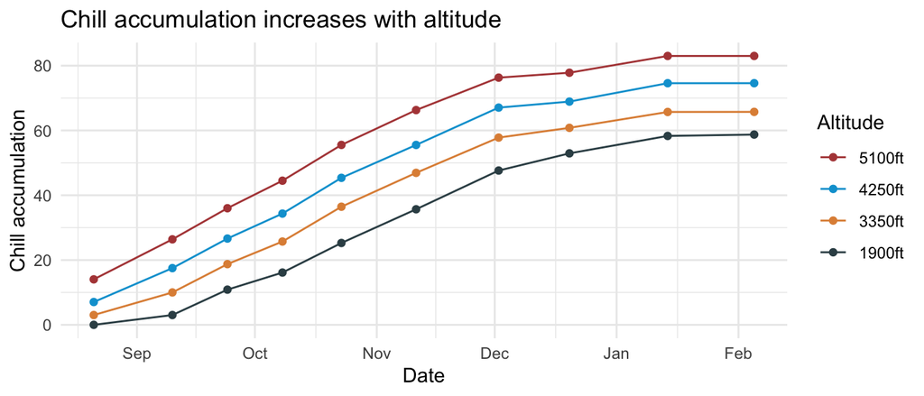

## iii) Estimate Deacclimation Rate

Note that the deacclimation rate is specific to a date of collection, altitude, and species. It refers to the estimated rate of decline in cold hardiness after a bud is subjected to forcing conditions. To estimate this value, we use a simple linear regression with $\rm{Cold \; hardiness} \sim \rm{Number \; of \; days \; under \; forcing} + \epsilon$ where $\epsilon$ is a Gaussian-distributed error term. Estimates are plotted in Figure 3.

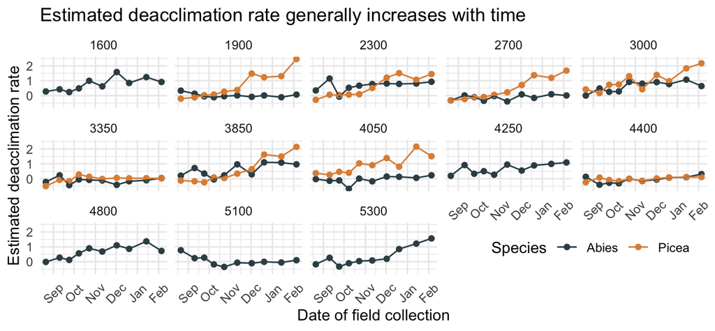

Figure 3: Estimated deacclimation rates (y-axis) are plotted for each date of collection (x-axis) and facted by altitude. Color represents species.

# Q1) How Are Buds in the Field Responding to Air Temperature to Change Their Cold Hardiness Over Time?

Because we are interested in how buds are responding to air temperature, we will consider accumulated chill as the “main” driver of cold hardiness. `Chill accumulation` encapsulates both time and weather. To inform our model selection, we start by plotting `Cold hardiness` as a function of `Chill accumulation`. For each altitude and species, we generally see a negative association with chill accumulation. This is expected since we know that as a tree is exposed to cold weather its `Cold hardiness` goes down. For a given elevation, the *Picea rubens* slope is generally steeper than the *Abies balsamea* slope, while its intercept is typically larger. This indicates that *Picea rubens* have a higher innate (i.e. worse) cold hardiness, but catch up to *Abies balsamea* as they undergo more time in the cold. There is also some variability due to sub-sampling (seen by the spread of points vertically at a fixed chill accumulation value) and collection date. For example, the fourth collection date for *Picea rubens* is systematically lower than expected at 1900, 2300, 2700, and 3000 feet altitude.

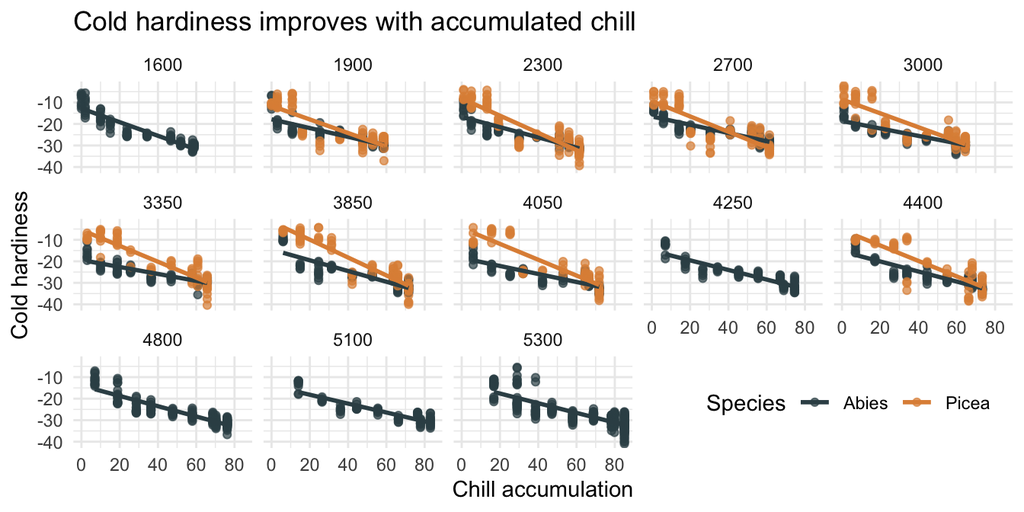

Figure 4: Each point represents a sub-sample measurement of cold hardiness (y-axis) for a given time (x-axis) over a range of altitudes (inset facets) and for both species (color).

## Q1) Analytical Strategy

We assume a linear mixed-effects model where `Cold hardiness` is a linear combination of `Chill accumulation` and `Species`. We include random effects for each distinct `Tree` and a random effect for each round (date) of `Collection`. `Chill accumulation` should capture time and temperature variability (and is highly correlated with time), so we do not include timet it as a covariate in this model. We define Tree ID is a unique identifier for each distinct tree used in the study. For the most part, since there is only one biological replicate per `Altitude` and `Species`, there is one unique tree for each `Altitude` and `Species`. So a particular tree’s random effect is indistinguishable from an `Altitude`:`Species` random effect (of course this is not the case when there are biological replicates). Our model is written below.

$\rm{Cold \; hardiness} \sim \rm{Intercept} + \rm{Chill\; accumulation} + \rm{Species} + \rm{Chill\; accumulation:Species} + (1|Tree \; random \; effect) + (1|Collection \; random \; effect) + \epsilon \quad (M1)$

We make the standard linear model assumptions: (i) that `Cold hardiness` is in fact a linear combination of the other variables, that the error terms, $\epsilon$, are (ii) independent and (iii) drawn from a Gaussian distribution with constant variance.

## Q1) Result: Chill Accumulation is Significant Predictor of Cold Hardiness

To test whether (a) there is a chill accumulation effect and (b) there is a species-specific chill accumulation effect, we compare the full model (above) with two reduced models. The simplest of the two reduced models omits the `Species` and `Species`:`Chill accumulation` interaction terms. The next simplest model allows a `Chill accumulation` main effect to enter the model. Finally, we introduce the interaction (`Species`:`Chill accumulation`). We find that there is a significant chill accumulation effect $(p=0.0002)$ on cold hardiness. There is also a significant interaction effect $(p < 10^{-15})$. Therefore we retain original model, M1, for further analysis.

At the beginning of data collection, the average *Abies rubens* has a cold hardiness of about -22 degrees Celsius, with *Picea rubens*’s cold hardiness about 9 degrees Celsius higher ($\approx$ -13 degrees). Holding all else constant, one unit of accumulated chill corresponds to a $-0.08$ degree change in cold hardiness. Moreover, as chill accumulation increases, *Picea rubens*’ expected cold hardiness changes by an additional $-0.14$ degrees. This jibes with Figure 4, where *Picea rubens*’ cold hardiness improves more rapidly than that of its *Abies balsamea* neighbors.

In short, residuals show slight departure from normality. Otherwise, our model assumptions seem reasonable.

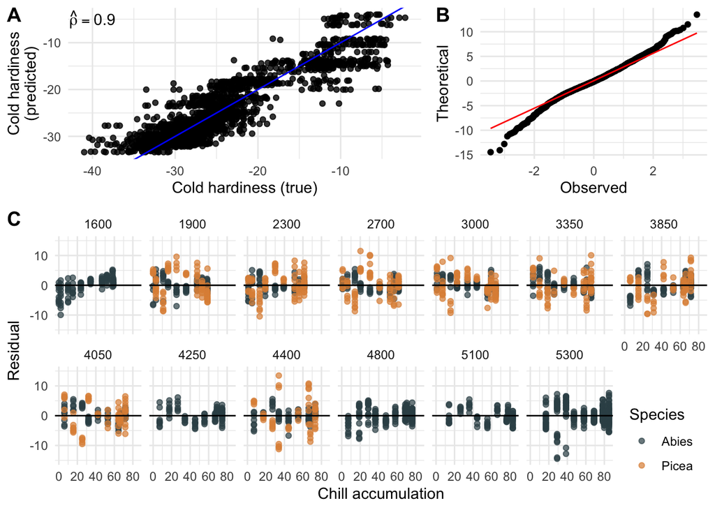

Figure 5: M1 Diagnostics. (A) Predicted (y-axis) cold hardiness plotted against true (x-axis). Each point represents one sub-sample; blue line indicates perfect prediction. (B) Normal quantile-quantile plot of model residuals. Red line indicates perfect concordance between distributions. Points away from the red line indicate non-normality. (C) Residuals (y-axis) plotted against chill accumulation (x-axis) for all altitudes (facets) and both species (color).

# Q2) Are There Ecotype Driven Changes in Deacclimation Rates?

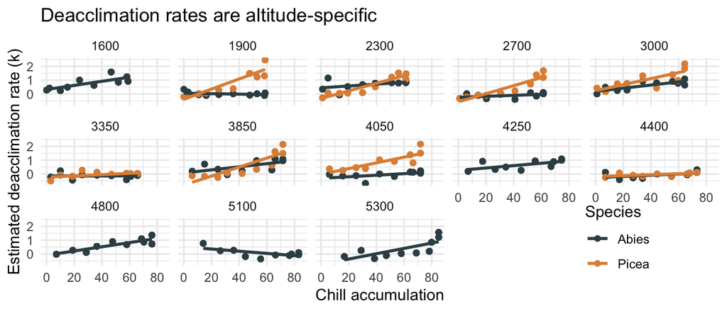

Figure 6: Deacclimation rates (y-axis) plotted as a function of cumulative chill (x-axis) by altitude (facet) and species (color).

## Q2) Analytical Strategy

We next turn to the second question by studying the potential relationship between altitude-specific ecotypes and deacclimation rates. As discussed with the client, field collections do not extend far enough into the spring to assess “real-world” deacclimation. Therefore, we are interested in understanding the estimated deacclimation rates. We assume the following linear model.

$$k^*_{\rm{Deacc}} \sim \rm{Categorical(Altitude)} + \rm{Species} + \rm{Chill \; accumulation} + \epsilon \quad (M2)$$

Here too $\epsilon$ represents the error term. We make the same assumptions as in **Q1) Analytical Strategy.** Note that `Altitude` is considered categorical in this analysis because we do not necessarily assume that the ecotypes change linearly with elevation. For example, one altitude could have more shade that selects for a phenotype. A tree at another altitude could have a stream running next to it that selects for a phenotype.

## Q2) Result: Ecotype Drives Changes in Deacclimation Rate

Using a similar procedure as outlined to answer the first question, we consider a simpler “nested” model that does not include an `Altitude` term. We find that there are differences in deacclimation rates that are accounted for by altitude that *are not* accounted for by chill accumulation ($p < 10^{-15}$). In other words, there are ecotype effects that are not explained by weather (i.e. chill accumulation).

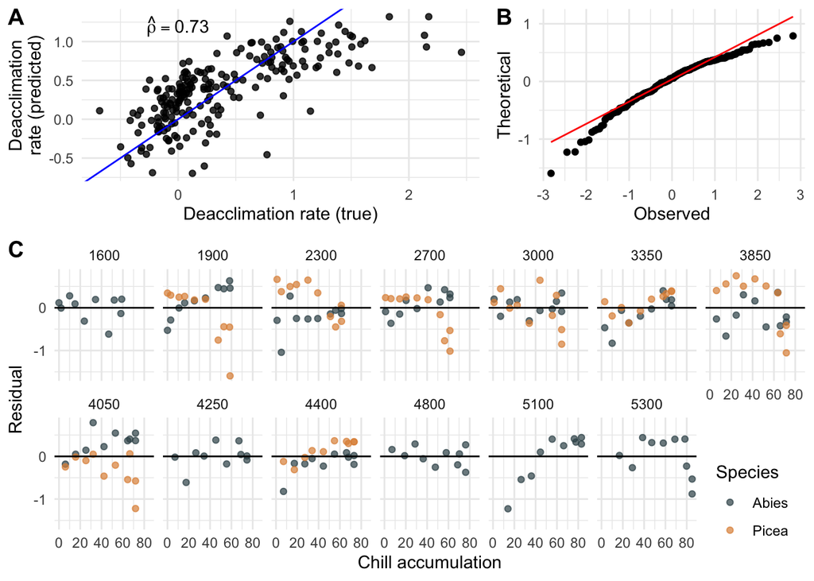

# Conclusion

## Summary of Results

We find that–as expected–cold hardiness improves with accumulated chill. One unit of accumulated chill corresponds to a $-0.08$ degree change in cold hardiness. This expected rate of change is more extreme for *Picea rubens*, as its expected cold hardiness changes by an additional $-0.14$ degrees (for a total of $-0.22$ degrees. We also report that deacclimation rates are ecotype specific. There are differences explained by altitude that are not accounted for by weather. Qualitatively, *Piceas rubens* have a higher deacclimation rate for most altitudes.

## Discussion

As previously mentioned in the data collection section, we need to be cautious about out-of-sample inference. Because the trees used in this study are not a random sample of trees on Mt. Washington, they may not fully represent the greater population. While not plotted in this report, we observe a general decrease in the number of subsamples as days under forcing increases. This could bias estimates of the deacclimation rate, especially for buds that did not undergo many days of forcing. Furthermore, using both species of trees in the same models could be problematic, as pointed out by the client in our consultation. We generally kept them together because they showed similar trends (for example cold hardiness improving with chill accumulation for both).

# Appendix

## Supplemental Figures

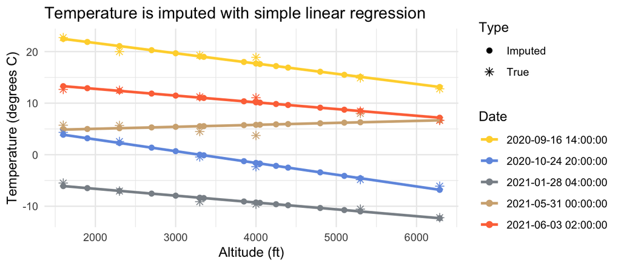

## Questions For Client

### Design & Data Collection

1. How were the trees selected used in the study selected?
2. Individuals “A” and “B” are not the same tree at different elevations. Is this also the case for different rounds of collection? In other words, is tree “A” on August 20 collection the same as tree “A” on January 13?
3. Does each measurement represent one cold hardiness score for one bud from one cutting from one tree? Is a sample the same as a cutting? Or are there instances where, to get ten buds, you need to retrieve multiple cuttings?
4. When running the differential thermal analysis / cold hardiness assay does the bud get expended? I don’t think so since there are repeated measurements. If you are using the same bud, do the differential thermal analyses give similar quality cold hardiness estimates?
5. Did the same technician or scientist perform all the collections and assays?
6. Are “day-of” field measurements performed on the same machine (TEM/freezer)?

### Data Missingness & QA

7. What causes missingness in the cold hardiness data (peak detection fails)? Is it random, or is it patterned in some way?
8. What’s going on with BT01 and BT02? It deviates from the pattern / convention of “A”, “B”, “C”, etc.
9. Cold hardiness data has a note that says temperatures need to be converted to negative—is this simply “times -1”?
10. There are 3002 missing values from the Mt. Washington Weather Stations. All are from the station at 4,300 feet. I assume we want to impute. Is it reasonable to impute with a linear model as we will do with the tree elevations not measured? Should we trust this station less?
11. With respect to interpolating for altitude values not measured—can we use a linear model?

### Modeling

12. Are you—generally speaking—more interested in the deacclimation rate or the cold hardiness on the day of collection? We can treat either (or both) as output variables?
13. Is there a “gold standard” model for estimating de-acclimation rate? Simple linear regression?
14. To answer question 1—how are buds responding to air temperature over time—is it reasonable to approach this in the following two ways?
1. First, look at cold hardiness on the day of collection as a function of cumulative chill (+ tree species, some random effects).
2. Second, look at deacclimation rate associated with one of the ten days of collection as a function of cumulative chill.
15. Should the two species of trees be used in the same model? Or given a separate treatment?
16. For the second question, you ask about differences explained by ecotypes versus differences explained by weather. Are you more interested in differences in “day-of” cold hardiness? Or differences in deacclimation rate? Something else?